# Red Wine Report

Maan Al Neami

2022-06-16

## Introdution

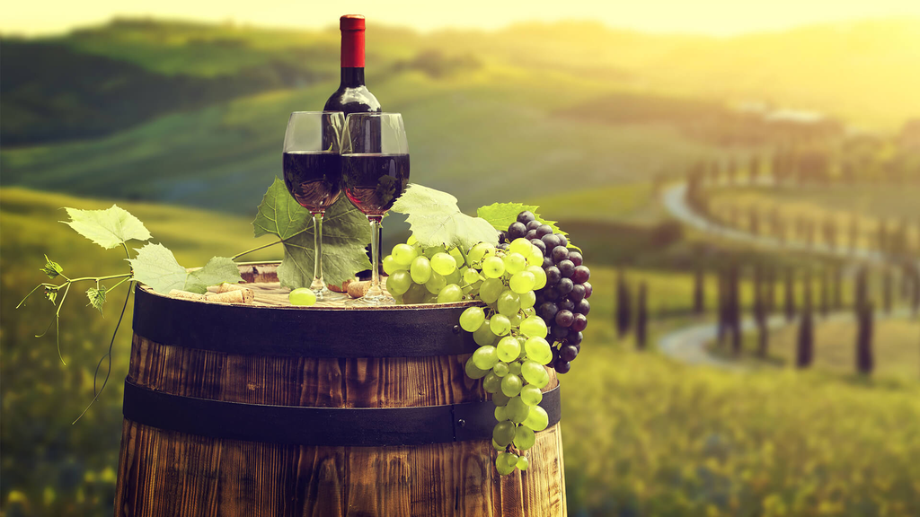

In this report we will be taking a look at a Red Wine dataset. The wine is called “vinho verde” wine from Portugal. We will be trying to find relationship between quality and other variables in the dataset. We will also be performing exploratory data analysis (EDA) on the dataset.

## Data

As mentioned above, the dataset is about red wine samples (vinho verde) from Portugal. The data was collected from May 2004 to February 2007. Only chemical properties of the wine are included here. There is no data about grape types, wine brand or age, which to my limited knowledge(from movies and games) are important factors for wine quality. There is 12 variables in this dataset, here they are:

| Variable | Description |
| --- | --- |
| fixed_acidity | Tartaric acid, it’s important for the wine and its color and taste of the finished wine. |
| volatile_acidity | Acetic acid tastes like vinegar. |
| citric_acid | adds flavor and freshness to wine. |
| residual_sugar | The remaining sugar after fermentation. |
| chlorides | Sodium chloride and it shows the amount of salt in wine. |
| free_sulfur_dioxide | the free form of Sulfur Dioxide(SO2), it prevents the oxidation of wine. |
| total_sulfur_dioxide | Total Sulfur Dioxide(SO2). |
| density | The density of wine which depends on the alcohol percentage and sugar. |
| pH | Measurement of how acidic or basic a wine is, usually between 3-4. |
| sulphates | A wine additive to prevents oxidation. |
| alcohol | The alcohol percentage in wine. |
| quality | Quality ranking of wine, between 0 and 10. |

*First lets load our data*

```r
wine <- read.csv(here("data/winequality-red.csv"))
```

*Second lets clean the data using `clean.names()` from janitor package and store it in new object*

```r
names(wine)[9] <- "ph"
wine %>%
  clean_names() -> wine_df
```

*Lets also check for missing values*

```r
sum(is.na(wine_df))
```

```
## [1] 0
```

Our dataset doesn’t contain any missing values so we don’t need to do further cleaning.

*Interactive table*

```r
reactable(wine_df)
```

| fixed_acidity | volatile_acidity | citric_acid | residual_sugar | chlorides | free_sulfur_dioxide | total_sulfur_dioxide | density | ph | sulphates | alcohol | quality |
| --- | --- | --- | --- | --- | --- | --- | --- | --- | --- | --- | --- |
| 7.4 | 0.7 | 0 | 1.9 | 0.076 | 11 | 34 | 0.9978 | 3.51 | 0.56 | 9.4 | 5 |
| 7.8 | 0.88 | 0 | 2.6 | 0.098 | 25 | 67 | 0.9968 | 3.2 | 0.68 | 9.8 | 5 |
| 7.8 | 0.76 | 0.04 | 2.3 | 0.092 | 15 | 54 | 0.997 | 3.26 | 0.65 | 9.8 | 5 |
| 11.2 | 0.28 | 0.56 | 1.9 | 0.075 | 17 | 60 | 0.998 | 3.16 | 0.58 | 9.8 | 6 |
| 7.4 | 0.7 | 0 | 1.9 | 0.076 | 11 | 34 | 0.9978 | 3.51 | 0.56 | 9.4 | 5 |
| 7.4 | 0.66 | 0 | 1.8 | 0.075 | 13 | 40 | 0.9978 | 3.51 | 0.56 | 9.4 | 5 |
| 7.9 | 0.6 | 0.06 | 1.6 | 0.069 | 15 | 59 | 0.9964 | 3.3 | 0.46 | 9.4 | 5 |
| 7.3 | 0.65 | 0 | 1.2 | 0.065 | 15 | 21 | 0.9946 | 3.39 | 0.47 | 10 | 7 |
| 7.8 | 0.58 | 0.02 | 2 | 0.073 | 9 | 18 | 0.9968 | 3.36 | 0.57 | 9.5 | 7 |
| 7.5 | 0.5 | 0.36 | 6.1 | 0.071 | 17 | 102 | 0.9978 | 3.35 | 0.8 | 10.5 | 5 |

[output cut: 1589 more lines]

# EDA

Here we will be exploring and visualizing our data

*First, we will exploring our data using `glimpse()` to see the dimensions of the dataset and the type of variables*

```r
glimpse(wine_df)
```

```
## Rows: 1,599
## Columns: 12
## $ fixed_acidity        <dbl> 7.4, 7.8, 7.8, 11.2, 7.4, 7.4, 7.9, 7.3, 7.8, 7.5…
## $ volatile_acidity     <dbl> 0.700, 0.880, 0.760, 0.280, 0.700, 0.660, 0.600, …
## $ citric_acid          <dbl> 0.00, 0.00, 0.04, 0.56, 0.00, 0.00, 0.06, 0.00, 0…
## $ residual_sugar       <dbl> 1.9, 2.6, 2.3, 1.9, 1.9, 1.8, 1.6, 1.2, 2.0, 6.1,…
## $ chlorides            <dbl> 0.076, 0.098, 0.092, 0.075, 0.076, 0.075, 0.069, …
## $ free_sulfur_dioxide  <dbl> 11, 25, 15, 17, 11, 13, 15, 15, 9, 17, 15, 17, 16…
## $ total_sulfur_dioxide <dbl> 34, 67, 54, 60, 34, 40, 59, 21, 18, 102, 65, 102,…
## $ density              <dbl> 0.9978, 0.9968, 0.9970, 0.9980, 0.9978, 0.9978, 0…
## $ ph                   <dbl> 3.51, 3.20, 3.26, 3.16, 3.51, 3.51, 3.30, 3.39, 3…
## $ sulphates            <dbl> 0.56, 0.68, 0.65, 0.58, 0.56, 0.56, 0.46, 0.47, 0…
## $ alcohol              <dbl> 9.4, 9.8, 9.8, 9.8, 9.4, 9.4, 9.4, 10.0, 9.5, 10.…
## $ quality              <int> 5, 5, 5, 6, 5, 5, 5, 7, 7, 5, 5, 5, 5, 5, 5, 5, 7…
```

we see here that the dimensions of our data is 1599 of rows and 12 cols, and all variables are double type except for `quality` which is an integer.

*Lets also use `summary()` fo further explore the dataset*

```r
summary(wine_df)
```

```
##  fixed_acidity   volatile_acidity  citric_acid    residual_sugar
##  Min.   : 4.60   Min.   :0.1200   Min.   :0.000   Min.   : 0.900
##  1st Qu.: 7.10   1st Qu.:0.3900   1st Qu.:0.090   1st Qu.: 1.900
##  Median : 7.90   Median :0.5200   Median :0.260   Median : 2.200
##  Mean   : 8.32   Mean   :0.5278   Mean   :0.271   Mean   : 2.539
##  3rd Qu.: 9.20   3rd Qu.:0.6400   3rd Qu.:0.420   3rd Qu.: 2.600
##  Max.   :15.90   Max.   :1.5800   Max.   :1.000   Max.   :15.500
##    chlorides       free_sulfur_dioxide total_sulfur_dioxide    density
##  Min.   :0.01200   Min.   : 1.00       Min.   :  6.00       Min.   :0.9901
##  1st Qu.:0.07000   1st Qu.: 7.00       1st Qu.: 22.00       1st Qu.:0.9956
##  Median :0.07900   Median :14.00       Median : 38.00       Median :0.9968
##  Mean   :0.08747   Mean   :15.87       Mean   : 46.47       Mean   :0.9967
##  3rd Qu.:0.09000   3rd Qu.:21.00       3rd Qu.: 62.00       3rd Qu.:0.9978
##  Max.   :0.61100   Max.   :72.00       Max.   :289.00       Max.   :1.0037
##        ph          sulphates         alcohol         quality
##  Min.   :2.740   Min.   :0.3300   Min.   : 8.40   Min.   :3.000
##  1st Qu.:3.210   1st Qu.:0.5500   1st Qu.: 9.50   1st Qu.:5.000
##  Median :3.310   Median :0.6200   Median :10.20   Median :6.000
##  Mean   :3.311   Mean   :0.6581   Mean   :10.42   Mean   :5.636
##  3rd Qu.:3.400   3rd Qu.:0.7300   3rd Qu.:11.10   3rd Qu.:6.000
##  Max.   :4.010   Max.   :2.0000   Max.   :14.90   Max.   :8.000
```

We see that the `quality` of the wine in this dataset is between 3 to 8, with no wine quality of 1, 2, 9, 10

*Plotting*

*Lets take a look at the distribution of our data by quality*

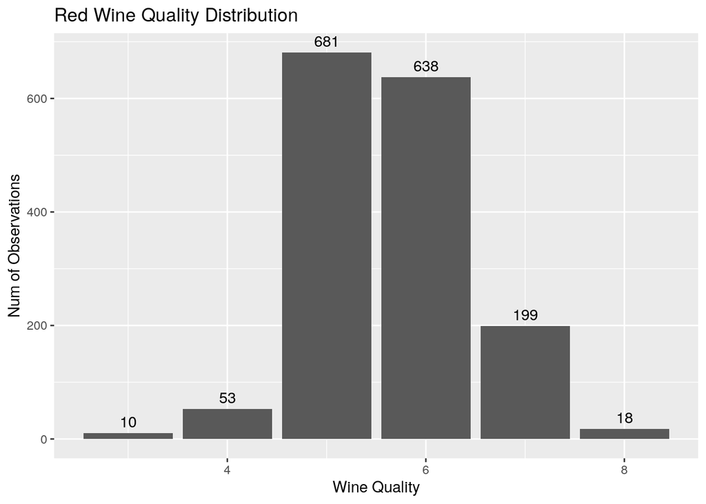

```r
ggplot(wine_df, aes(x=quality, color = wine_df$quality)) +
  geom_bar(stat="count") +
  geom_text(position = "stack", stat='count',aes(label=..count..), vjust = -0.5)+
  labs(y="Num of Observations", x="Wine Quality") +
  labs(title= "Red Wine Quality Distribution")
```

We can see from this graph that most of our data is in mid range quality between 5-6 with few very high or low quality wine.

*Lets also take a look at the correlation heatmap*

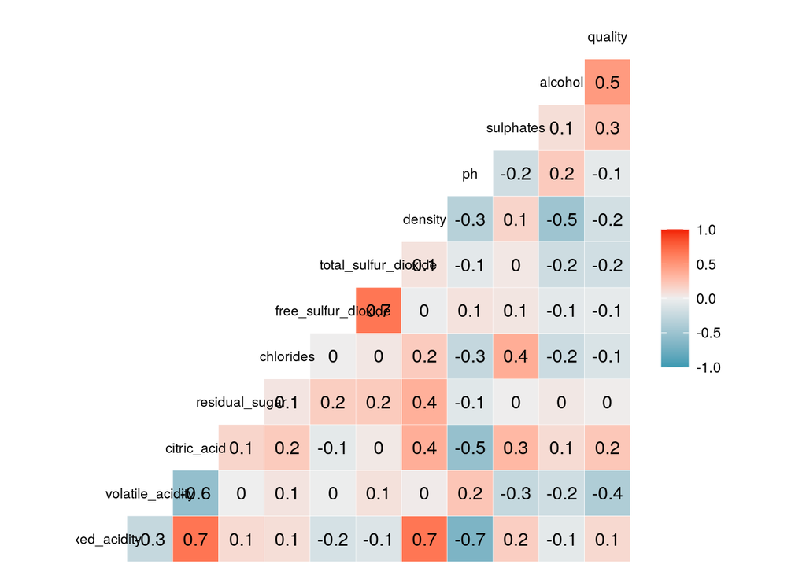

```r
ggcorr(wine_df, label=TRUE, size = 3)
```

And negative correlation with:

1. `volatile_acidity` with -0.4

We also see negative correlation between `alcohol` and `density` which makes sense because alcohol has lower density than wine. We also see positive correlation between `density` and `fix_acidity`, but a negative correlation between `pH` and `fix_acidity.` As mentioned before, we will be exploring the correlation between quality and the high correlation variables listed above.

*Next, we will look at the distribution of the numeric variables via histograms:*

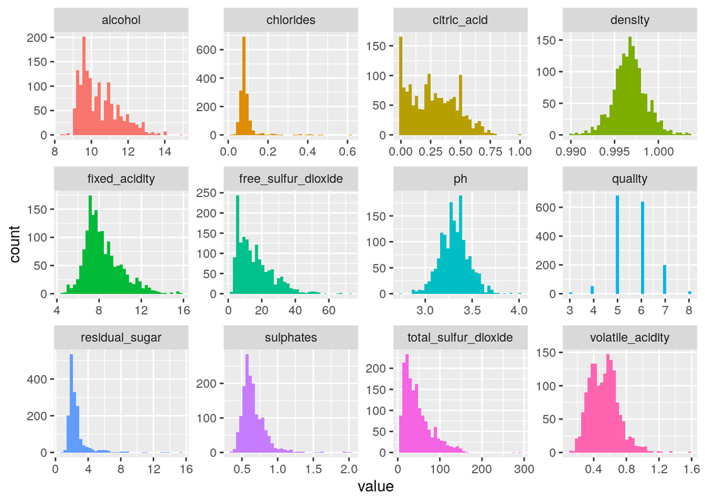

```r
wine_df %>%
  keep(is.numeric) %>%
  gather() %>%
  ggplot(aes(value,fill=key)) +
  facet_wrap(~ key, scales = "free") +
  geom_histogram(bins=sqrt(nrow(wine_df))) +
  theme(legend.position="none")
```

We can see that `density` and `pH` seem to be symmetric, so the distribution looks like a normal distribution. `volatile_acidity` also shows a somewhat normal distribution. Looking at the remaining variables, we can see that a number of distributions are positively skewed, like `chlorides`, `fixed_acidity`, `residual_sugar`, `sulphates` among others. Which means these distributions have mostly lower end values with a few wines with relatively higher values.

*Lets see the effect of `sulphates`, `alcohol` and `volatile_acidity` values on the wine `quality`.*

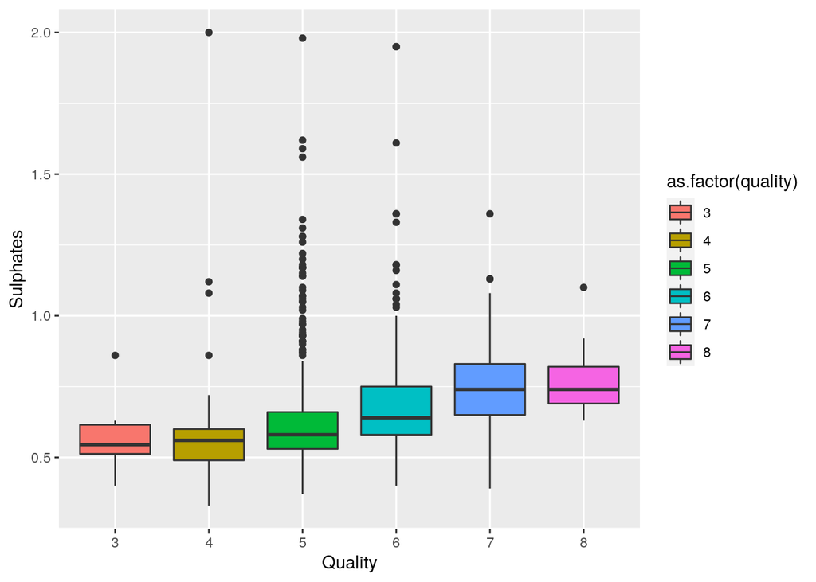

```r
ggplot(wine_df, aes(x=as.factor(quality), y=sulphates, fill=as.factor(quality))) +
  geom_boxplot() +
  labs(x = "Quality", y="Sulphates")
```

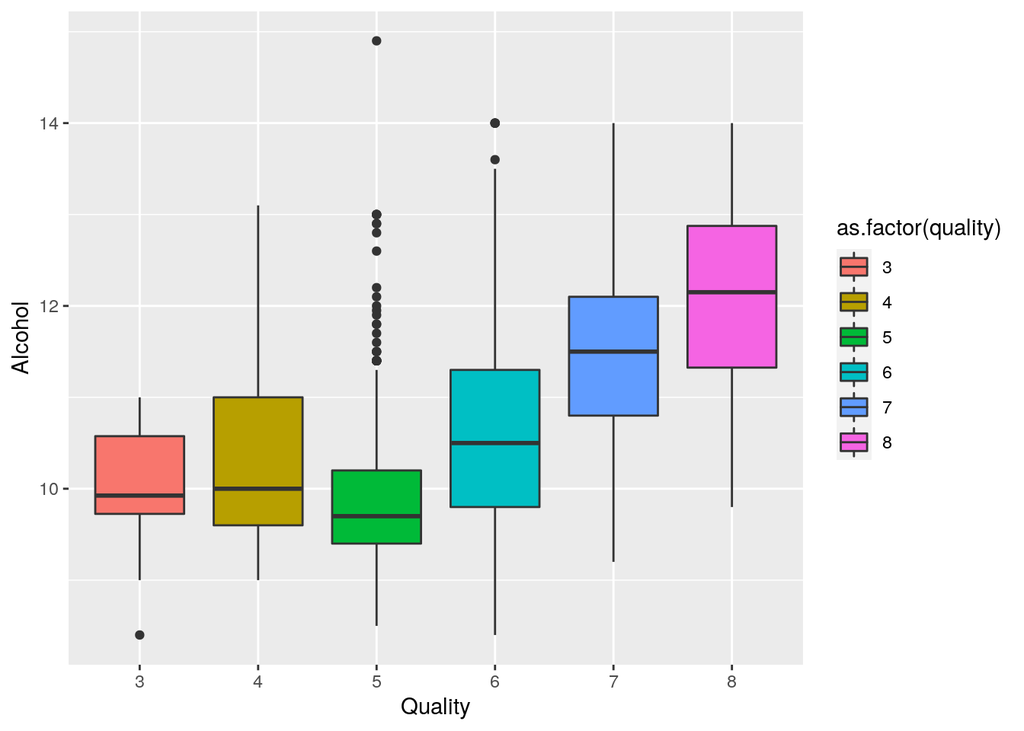

```r
ggplot(wine_df, aes(x=as.factor(quality), y=alcohol, fill=as.factor(quality))) +
  geom_boxplot() +
  labs(x = "Quality", y="Alcohol")
```

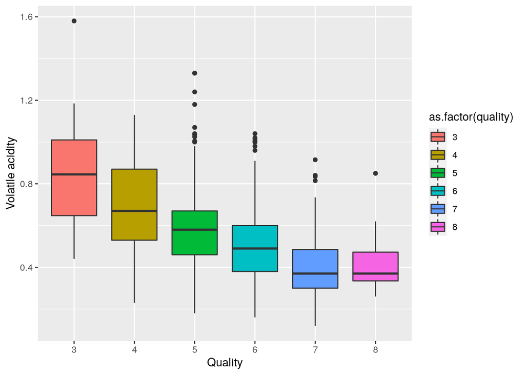

```r
ggplot(wine_df, aes(x=as.factor(quality), y=volatile_acidity, fill=as.factor(quality))) +
  geom_boxplot() +
  labs(x = "Quality", y="Volatile acidity")
```

Looking at the above plots, it becomes clear that `quality` has a positive correlation with both `alcohol` and `sulphates` and negative correlation with `volatile_acidity`. We can also see that data of `quality` 5 and 6 have a lot of outliers but that’s probably because the make up most of our sample.

# Conclusion

After exploring our data, we might have ended up with more questions than answers. Because although we were able to find that `alcohol` and `sulphates` effect `quality` positively, while `volatile_acidity` effected it negatively. We can’t be fully sure because of the small size of our high and low `quality` wine sample. We will need a bigger dataset with more variation in its sample to accurately determine what variables effect quality the most. But for now I think this is good enough for now.